# Harnessing big data for agricultural excellence

Part 2: Diagnosing and implementing big data solutions

[figure not shown]

Marie-Hélène Burle

Simon Fraser University’s Big Data Hub &  
BC Centre for Agritech Innovation

November 21, 2024

[figure not shown]

# Who we are

## Simon Fraser University

[SFU](https://www.sfu.ca/) hosts the [Cedar supercomputer](https://www.sfu.ca/research/supercomputer-cedar)—a cluster of 100,400 CPUs and 1,352 GPUs [soon to be replaced by an even larger computer cluster](https://www.sfu.ca/sfunews/stories/2024/06/sfu-awarded--80-million-to-upgrade-supercomputing-facility-.html)

[figure not shown]

## Simon Fraser University

[SFU](https://www.sfu.ca/) also works with the [Digital Research Alliance of Canada](https://alliancecan.ca/en) to offer researchers large amounts of computing power to solve challenging data and technology problems, as well as training to optimize their solutions

[figure not shown]

## SFU’s Big Data Hub

Since 2016, [Simon Fraser University’s Big Data Hub](https://www.sfu.ca/big-data.html) has been offering workshops, events, and consulting services to researchers and industry partners helping them remain at the top of the fast evolving data landscape

[figure not shown]

## BC Centre for Agritech Innovation

Since 2022, [SFU BCCAI](https://www.sfu.ca/agritech-innovation.html) has been helping small and medium enterprises in the farming industry to embrace technology driven solutions

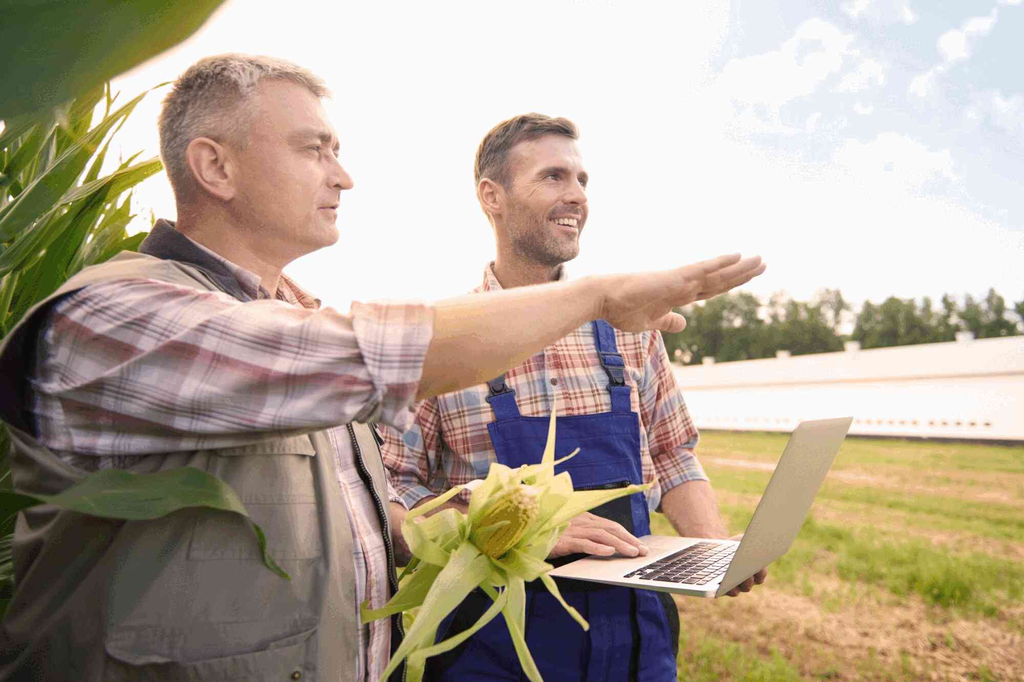

## BC Centre for Agritech Innovation

[figure not shown]

# Goals for this workshop

## Session 1

A (hopefully) friendly lecture to:

- Demystify big data
- Demonstrate the critical importance of big data in agriculture and farming

[figure not shown]

## Session 1 recap

Big data is defined by the 3 “V”:

- Volume (lots of data is generated)
- Variety (images, sounds, text…)
- Velocity (generated continuously)

[figure not shown]

## Session 1 recap

Big data has become crucial because it allows you to train artificial intelligence models

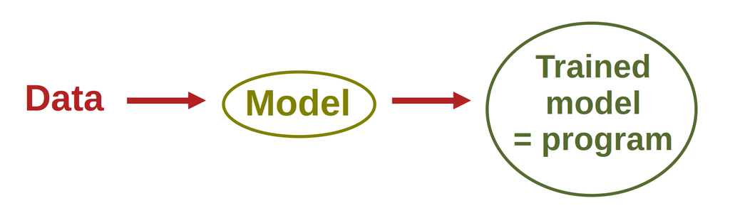

## Session 1 recap

Once trained, those models are extremely powerful and capable of performing tasks impossible for traditional computer programs

(e.g. creating art, generating human text, chat bots, excellent forecasting and optimization, computer vision, self-driving cars…)

[figure not shown]

## Session 1 recap

Big data and AI are transforming all sectors, including agriculture because they allow:

- Real time monitoring
- Better decision making
- Optimizations
- Automation of tasks

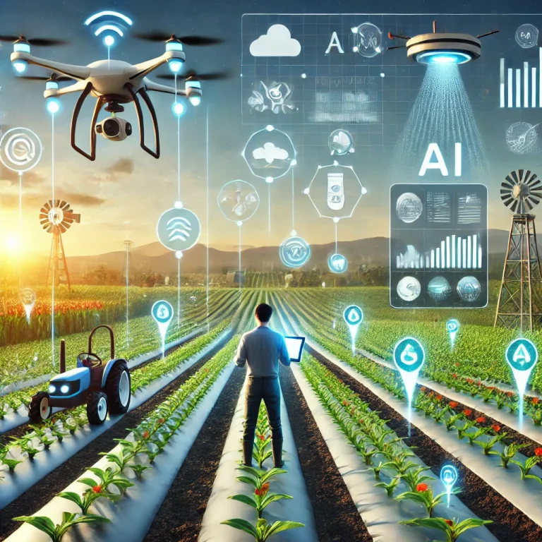

## Session 1 recap

However there are challenges to the implementation of such transformative methods

- Infrastructure development
- Skill gaps among agricultural professionals

We are here to help  
This is the goal of today’s session

[figure not shown]

[figure not shown]

## Session 2

An interactive workshop to:

- Brainstorm on how big data can benefit your operation
- Help you make the transition to smart farming

[figure not shown]

## Data management

First, let’s focus on your data

I will ask you to think about:

- The data you use for your operation
- How you are collecting it and storing it
- How you could automate this

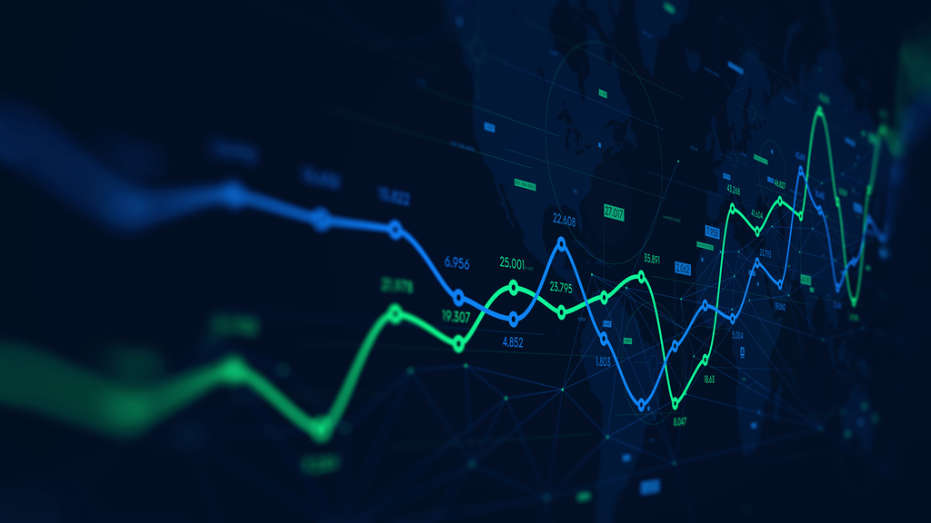

## Analytics

Now, let’s think about what this data is actually used for:

- What is purpose of this data?
- How do you analyse it?
- What could be the benefits of using AI to process your data?

[figure not shown]

## Challenges

What are the challenges of such an implementation

- at the financial level
- at the practical level
- due to knowledge gaps

[figure not shown]

From [xkcd.com](https://xkcd.com/)

## Who to turn to?

Connecting with other operators can be extremely powerful in this transformation

You may also need to talk with researchers

You will need to find a technology provider

Here my colleagues from the Big Data Hub and the BCCAI will jump in to orientate you

### SFU’s Big Data Hub

[Website](https://www.sfu.ca/big-data.html)  
[Contact us](https://www.sfu.ca/big-data/about-us/contact-us.html)  
[Consultation services](https://www.sfu.ca/big-data/about-us/consultation-services.html)  
Partnerships

[Website](https://www.sfu.ca/agritech-innovation.html)  
[Contact us](https://www.sfu.ca/agritech-innovation/connect/contact.html)  
[Agritech development program](https://www.sfu.ca/agritech-innovation/programs/agritech-development-program/application.html)  
[Training](https://www.sfu.ca/agritech-innovation/training-upskilling.html)

## Communication with experts

You need basic concepts and vocabulary to communicate your needs to technology providers and researchers

- What concept do you feel that you are lacking and that we should cover?
- Vocabulary clarification

[figure not shown]

From [xkcd.com](https://xkcd.com/)

# Resources

## Understanding neural networks

[3Blue1Brown by Grant Sanderson](https://www.3blue1brown.com/) has a series of 4 videos on neural networks which is easy to watch, fun, and does an excellent job at introducing the functioning of a simple neural network

[video not shown]

## Literature

Open-access preprints:

[ML papers in the computer science category on arXiv](https://arxiv.org/list/cs.LG/recent)  
[ML papers in the stats category on arXiv](https://arxiv.org/list/stat.ML/recent)  
[Distill ML research online journal](https://distill.pub/)

## Acknowledgements

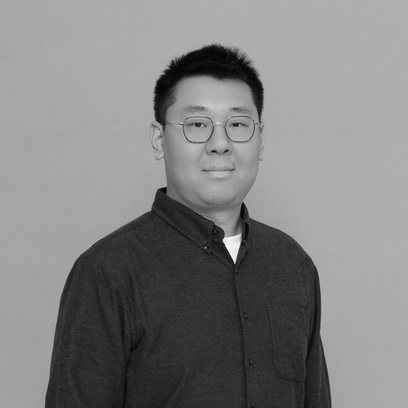

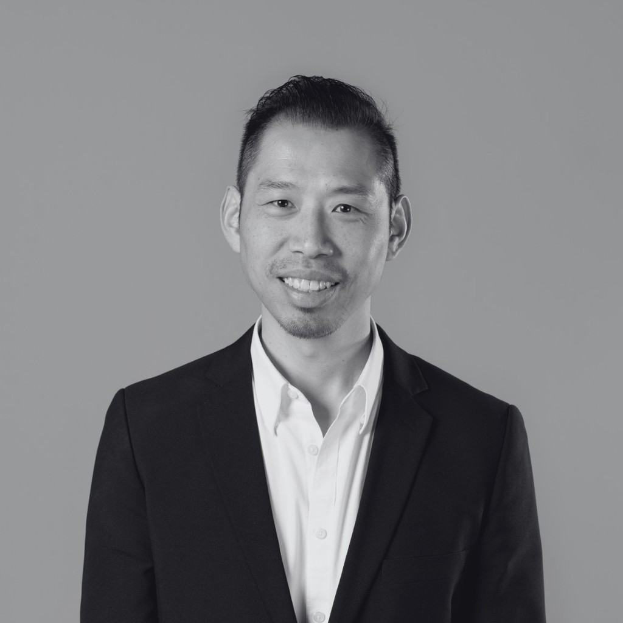

[Carson Li](https://www.sfu.ca/agritech-innovation/about-us/team/carson-li.html) ([BCCAI](https://www.sfu.ca/agritech-innovation.html)) suggested an outline for this talk

[Ian Chan](https://www.linkedin.com/in/ianychan/?originalSubdomain=ca) ([BCCAI](https://www.sfu.ca/agritech-innovation.html)) provided copious feedback